# Reproducible Research: Peer Assessment 1

## Loading and preprocessing the data

```r
activity <- read.csv("activity/activity.csv", colClasses = c("numeric", "character", "numeric"))
head(activity)
```

```
##   steps       date interval
## 1    NA 2012-10-01        0
## 2    NA 2012-10-01        5
## 3    NA 2012-10-01       10
## 4    NA 2012-10-01       15
## 5    NA 2012-10-01       20
## 6    NA 2012-10-01       25
```

```r
names(activity)
```

```
## [1] "steps"    "date"     "interval"
```

**Converting to date from character**

```r
activity$date <- as.Date(activity$date, "%Y-%m-%d")
```

## What is mean total number of steps taken per day?

```r
totalStepsPerDay <- aggregate(steps ~ date, data = activity, sum, na.rm = TRUE)
```

**The plot for total steps by day is shown below**

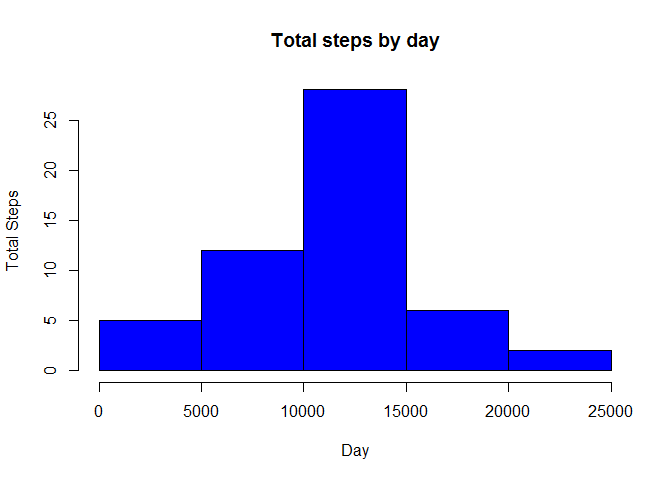

```r
hist(totalStepsPerDay$steps, main = "Total steps by day", xlab = "Day", ylab = "Total Steps", col = "blue")
```

**The mean for total teps per day is calculated below**

```r
mean(totalStepsPerDay$steps)
```

```
## [1] 10766.19
```

**The median of total steps per day is calculated below**

```r
median(totalStepsPerDay$steps)
```

```
## [1] 10765
```

## What is the average daily activity pattern?

**The average steps per time interval is calculated below**

```r
avgStepsPerInterval <- aggregate(steps ~ interval, data = activity, mean, na.rm = TRUE)
```

**The time series plot is shown below**

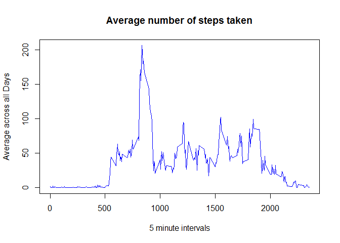

```r
plot(avgStepsPerInterval, type = "l", xlab = "5 minute intervals",
    ylab = "Average across all Days", main = "Average number of steps taken", col = "blue")
```

**The time interval with the maximum number of steps is**

```r
avgStepsPerInterval[which.max(avgStepsPerInterval$steps),1]
```

```
## [1] 835
```